# Logistic Regression - Heart Disease

Debartha Paul

2023-05-23

## Logistic Regression - Heart Disease

We’ll be doing a Logistic Regression for the Heart Disease Dataset available at [Kaggle](https://www.kaggle.com/datasets/johnsmith88/heart-disease-dataset).

## Loading and cleaning data

We first load the dataset:

```r
heart <- read.csv("D:\\Important Documents\\GSSoC'23\\heart.csv")
names(heart)
```

```
 [1] "age"      "sex"      "cp"       "trestbps" "chol"     "fbs"
 [7] "restecg"  "thalach"  "exang"    "oldpeak"  "slope"    "ca"
[13] "thal"     "target"
```

```r
dim(heart)
```

```
[1] 1025   14
```

```r
summary(heart)
```

```
      age             sex               cp            trestbps
 Min.   :29.00   Min.   :0.0000   Min.   :0.0000   Min.   : 94.0
 1st Qu.:48.00   1st Qu.:0.0000   1st Qu.:0.0000   1st Qu.:120.0
 Median :56.00   Median :1.0000   Median :1.0000   Median :130.0
 Mean   :54.43   Mean   :0.6956   Mean   :0.9424   Mean   :131.6
 3rd Qu.:61.00   3rd Qu.:1.0000   3rd Qu.:2.0000   3rd Qu.:140.0
 Max.   :77.00   Max.   :1.0000   Max.   :3.0000   Max.   :200.0
      chol          fbs            restecg          thalach
 Min.   :126   Min.   :0.0000   Min.   :0.0000   Min.   : 71.0
 1st Qu.:211   1st Qu.:0.0000   1st Qu.:0.0000   1st Qu.:132.0
 Median :240   Median :0.0000   Median :1.0000   Median :152.0
 Mean   :246   Mean   :0.1493   Mean   :0.5298   Mean   :149.1
 3rd Qu.:275   3rd Qu.:0.0000   3rd Qu.:1.0000   3rd Qu.:166.0
 Max.   :564   Max.   :1.0000   Max.   :2.0000   Max.   :202.0
     exang           oldpeak          slope             ca
 Min.   :0.0000   Min.   :0.000   Min.   :0.000   Min.   :0.0000
 1st Qu.:0.0000   1st Qu.:0.000   1st Qu.:1.000   1st Qu.:0.0000
 Median :0.0000   Median :0.800   Median :1.000   Median :0.0000
 Mean   :0.3366   Mean   :1.072   Mean   :1.385   Mean   :0.7541
 3rd Qu.:1.0000   3rd Qu.:1.800   3rd Qu.:2.000   3rd Qu.:1.0000
 Max.   :1.0000   Max.   :6.200   Max.   :2.000   Max.   :4.0000
      thal           target
 Min.   :0.000   Min.   :0.0000
 1st Qu.:2.000   1st Qu.:0.0000
 Median :2.000   Median :1.0000
 Mean   :2.324   Mean   :0.5132
 3rd Qu.:3.000   3rd Qu.:1.0000
 Max.   :3.000   Max.   :1.0000
```

We then convert to factors some of the predictors:

```r
heart$sex <- as.factor(heart$sex)
heart$cp <- as.factor(heart$cp)
heart$restecg <- as.factor(heart$restecg)
heart$fbs <- as.factor(heart$fbs)
heart$exang <- as.factor(heart$exang)
heart$slope <- as.factor(heart$slope)
heart$ca <- as.factor(heart$ca)
heart$thal <- as.factor(heart$thal)
summary(heart)
```

```
      age        sex     cp         trestbps          chol     fbs     restecg
 Min.   :29.00   0:312   0:497   Min.   : 94.0   Min.   :126   0:872   0:497
 1st Qu.:48.00   1:713   1:167   1st Qu.:120.0   1st Qu.:211   1:153   1:513
 Median :56.00           2:284   Median :130.0   Median :240           2: 15
 Mean   :54.43           3: 77   Mean   :131.6   Mean   :246
 3rd Qu.:61.00                   3rd Qu.:140.0   3rd Qu.:275
 Max.   :77.00                   Max.   :200.0   Max.   :564
    thalach      exang      oldpeak      slope   ca      thal
 Min.   : 71.0   0:680   Min.   :0.000   0: 74   0:578   0:  7
 1st Qu.:132.0   1:345   1st Qu.:0.000   1:482   1:226   1: 64
 Median :152.0           Median :0.800   2:469   2:134   2:544
 Mean   :149.1           Mean   :1.072           3: 69   3:410
 3rd Qu.:166.0           3rd Qu.:1.800           4: 18
 Max.   :202.0           Max.   :6.200
     target
 Min.   :0.0000
 1st Qu.:0.0000
 Median :1.0000
 Mean   :0.5132
 3rd Qu.:1.0000
 Max.   :1.0000
```

## Building the model

We first break the data into training and test sets:

```r
set.seed(2023)
x <- sample(1:nrow(heart), 0.8 * nrow(heart))
train <- heart[x,]
test <- heart[-x,]
```

Then we fit the model for logistic regression:

```r
model <- glm(target~., data=train, family=binomial)
summary(model)
```

```
Call:
glm(formula = target ~ ., family = binomial, data = train)

Coefficients:
             Estimate Std. Error z value Pr(>|z|)
(Intercept)  0.525285   2.740739   0.192 0.848010
age          0.024645   0.015948   1.545 0.122252
sex1        -2.459644   0.388241  -6.335 2.37e-10 ***
cp1          1.032312   0.361004   2.860 0.004242 **
cp2          2.302076   0.344639   6.680 2.39e-11 ***
cp3          2.944983   0.479997   6.135 8.49e-10 ***
trestbps    -0.029063   0.007766  -3.742 0.000182 ***
chol        -0.005896   0.002733  -2.157 0.030996 *
fbs1         0.458609   0.369110   1.242 0.214063
restecg1     0.310493   0.254556   1.220 0.222563
restecg2    -0.563385   1.870156  -0.301 0.763224
thalach      0.024769   0.008275   2.993 0.002762 **
exang1      -0.906281   0.287103  -3.157 0.001596 **
oldpeak     -0.434073   0.156572  -2.772 0.005565 **
slope1      -0.479677   0.551406  -0.870 0.384345
slope2       1.200196   0.578887   2.073 0.038146 *
ca1         -2.382199   0.342902  -6.947 3.73e-12 ***
ca2         -3.957278   0.556089  -7.116 1.11e-12 ***
ca3         -1.940632   0.594012  -3.267 0.001087 **
ca4          2.209683   1.080088   2.046 0.040772 *
thal1        2.910685   2.177946   1.336 0.181407
thal2        2.087512   2.134416   0.978 0.328062
thal3        0.647558   2.136844   0.303 0.761856
---
Signif. codes:  0 '***' 0.001 '**' 0.01 '*' 0.05 '.' 0.1 ' ' 1

(Dispersion parameter for binomial family taken to be 1)

    Null deviance: 1136.17  on 819  degrees of freedom
Residual deviance:  447.72  on 797  degrees of freedom
AIC: 493.72

Number of Fisher Scoring iterations: 7
```

What we actually do in the logistic regression is fit a model of the form
$$\log\frac{\pi}{1-\pi}=\beta_0+\beta_1x_1+\cdots+\beta_px_p$$
where $\pi$ is the probability of success (in this case, the probability of getting a heart disease)

## Prediction

We make use of the test set to predict the probability of getting a heart disease on an average:

```r
pred <- predict(model, newdata=test, type="response")
head(pred)
```

```
           1            4           14           15           17           22
0.0264064590 0.1029207605 0.0004650491 0.0593866714 0.8777491712 0.6919152732
```

## Tests of accuracy

```r
pchisq(model$null.deviance - model$deviance,
    model$df.null - model$df.residual,
    lower.tail=FALSE)
```

```
[1] 2.124315e-131
```

We note that the p-value of this test is $<0.05$. Hence we may reject the null hypothesis and conclude that our fitted model is better than the null model.

## ROC Curve and AUC

We’ll use the `pROC` package in R for the plots:

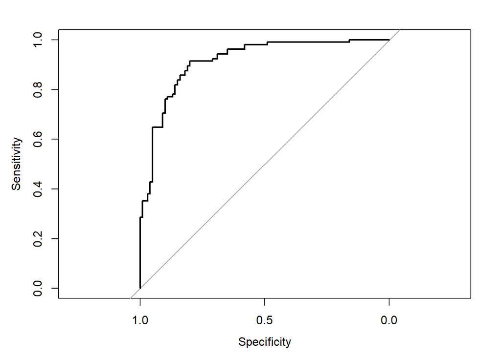

We finally find the AUC and note that:

```r
auc(roc(test$target, pred))
```

```
Area under the curve: 0.9142
```

An AUC value of $1$ implies an ideal case of perfect presiction whereas a value of 0.5 defaults down to a random prediction. As our value is very close to 1, we say that the model prediction is very good.